# SimulateRT_LBA

## Simulate RTs with a hierarchical LBA model (2stim x 2CohLevels x 2AngleLevels)

We use DMC for the Bayesian fitting of the hierarchical model. First thing first we need to invoke the model from DMC. DMC requires to set the working directory on its folder. Once loaded the model we can go back to our working directory and load the required libraries.

```r
wd <- here::here();

setwd("/Users/ale/ownCloud/3-R/DMC_190819/")
source("dmc/dmc.R")
load_model (dir_name="LBA",model_name="lba_B.R")

setwd(wd)

set.seed(123)#for reproducibility

pacman::p_load('tidyverse','magrittr')
```

# Set up the model

1- Define the factorial design: 2 motion directions x 2 coherence levels x 2 angles * s1/s2 left and right motion direction * cohE/cohH easy/hard coherence * angleE/angleH easy/hard angle

2 - Create “match.map”, a list of lists, where the first entry is a list named “M” that specifies which accumulator matches the correct response for each factor level. Accumulators can be specified by the corresponding response name or an integer 1..n for n response possibilities

3 - Create “const”, a vector which specifies the parameters to be held constant (i.e., not varied in fitting), and their values. In order to identify the model, the moment-to-moment variability of the accumulation rate is fixed to one, consitent with Sigmann et al., 2017.

```r
factors <- list(S=c("s1","s2"),Coh=c("cohE","cohH"),Angle=c("angleE","angleH"))
responses <- c("r1","r2") # keys o and p

match.map <- list(M=list(s1="r1",s2="r2"))

const <- c(sd_v.false=1,st0=0)
```

# Generate model1: manipulations affect decision boundary

- Create “p.map”, a list where the above specified factors are mapped onto the parameters of the model
- Generate model1

```r
# boundary  changes with manipulations, accum-rate faster for correct
p.map <- list(A="1",B=c("Coh","Angle"),t0="1",mean_v=c("M"),sd_v="M",st0="1")

model1 <- model.dmc(p.map,match.map = match.map,constants=const,
                   responses=responses,factors=factors)
```

```
##
## Parameter vector names are: ( see attr(,"p.vector") )
## [1] "A"             "B.cohE.angleE" "B.cohH.angleE" "B.cohE.angleH"
## [5] "B.cohH.angleH" "t0"            "mean_v.true"   "mean_v.false"
## [9] "sd_v.true"
##
## Constants are (see attr(,"constants") ):
## sd_v.false        st0
##          1          0
##
## Model type = norm (posdrift= TRUE )
```

# Simulate RTs from model1

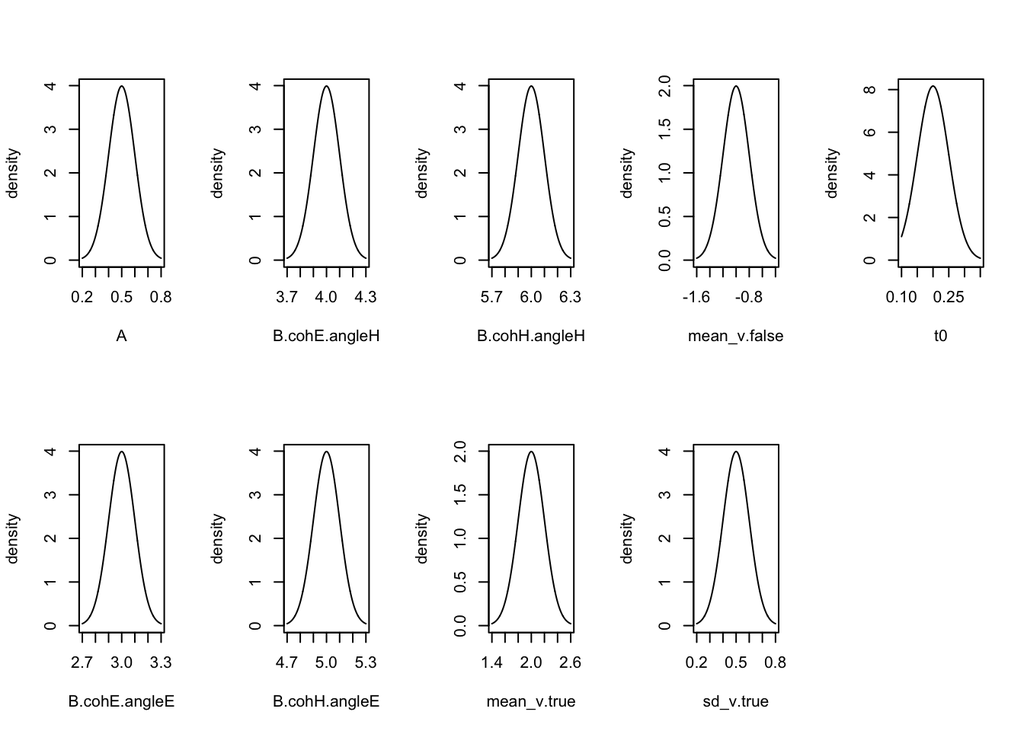

```r
pop.mean <- c(A=0.5, B.cohE.angleE = 3, B.cohE.angleH = 4, B.cohH.angleE = 5,
              B.cohH.angleH=6,mean_v.true=2,mean_v.false=-1,
              sd_v.true=0.5, t0=.2)

pop.scale <-c(A=.1, B.cohE.angleE = .1, B.cohE.angleH = .1, B.cohH.angleE = .1,
              B.cohH.angleH = .1,mean_v.true=.2,mean_v.false=.2,
              sd_v.true=0.1,t0=.05)

pop.prior <- prior.p.dmc(
  dists = rep("tnorm",9),
  p1=pop.mean,p2=pop.scale,
  lower=c(0,0,0,0,0,NA,NA,0,.1),upper=c(NA,NA,NA,NA,NA,NA,NA,NA,1)
)

##  Check population distributions
par(mfcol=c(2,5)); for (i in names(pop.prior)) plot.prior(i,pop.prior)
```

Simulate data: ns subjects, with n data point per design cell

```r
raw.data1 <- h.simulate.dmc(model1, p.prior = pop.prior, n = 250, ns = 40)
data.model1 <- data.model.dmc(raw.data1, model1)

# Take a look at parameters
ps <- round( attr(raw.data1, "parameters"), 2)
round(apply(ps,2,mean),2)
```

```
##             A B.cohE.angleE B.cohE.angleH B.cohH.angleE B.cohH.angleH
##          0.50          3.00          4.00          4.99          6.00
##   mean_v.true  mean_v.false     sd_v.true            t0
##          2.00         -0.98          0.52          0.21
```

Plot data from a subject:

First column=response left, Rows = EasyCoh-EasyAngle, EasyCoh-HardAngle,HardCoh-EasyAngle, HardCoh-HardAngle

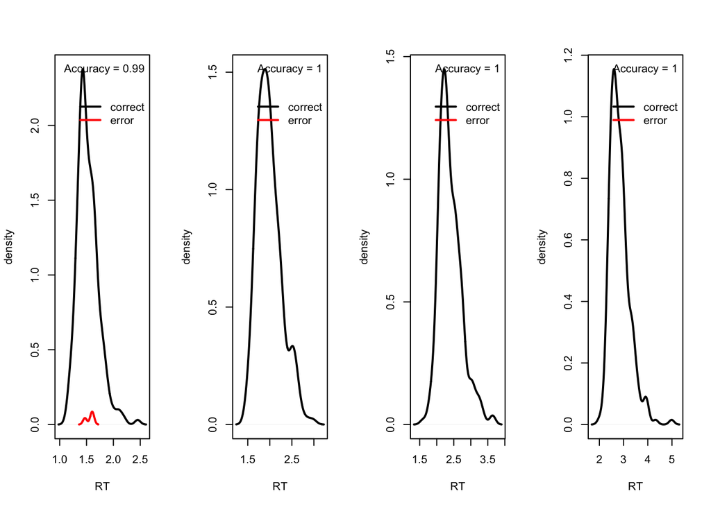

```r
par(mfcol=c(1,4))
for (i in 1) { # First column=response left, Second column = response right. Rows = EasyCoh-EasyAngle, EasyCoh-HardAngle,HardCoh-EasyAngle, hard-hard
  plot.cell.density(data.cell=data.model1[[i]][data.model1[[i]]$Coh=="cohE" & data.model1[[i]]$Angle=="angleE" & data.model1[[i]]$S=="s1",],C="r1",xlim=c(1,6),show.mean = TRUE)
  plot.cell.density(data.cell=data.model1[[i]][data.model1[[i]]$Coh=="cohE" & data.model1[[i]]$Angle=="angleH" & data.model1[[i]]$S=="s1",],C="r1",xlim=c(1,6),show.mean = TRUE)
  plot.cell.density(data.cell=data.model1[[i]][data.model1[[i]]$Coh=="cohH" & data.model1[[i]]$Angle=="angleE" & data.model1[[i]]$S=="s1",],C="r1",xlim=c(1,6),show.mean = TRUE)
  plot.cell.density(data.cell=data.model1[[i]][data.model1[[i]]$Coh=="cohH" & data.model1[[i]]$Angle=="angleH" & data.model1[[i]]$S=="s1",],C="r1",xlim=c(1,6),show.mean = TRUE)

  # plot.cell.density(data.cell=data.model1[[i]][data.model1[[i]]$Coh=="cohE" & data.model1[[i]]$Angle=="angleE" & data.model1[[i]]$S=="s2",],C="r2",xlim=c(1,6),show.mean = TRUE)
  # plot.cell.density(data.cell=data.model1[[i]][data.model1[[i]]$Coh=="cohE" & data.model1[[i]]$Angle=="angleH" & data.model1[[i]]$S=="s2",],C="r2",xlim=c(1,6),show.mean = TRUE)
  # plot.cell.density(data.cell=data.model1[[i]][data.model1[[i]]$Coh=="cohH" & data.model1[[i]]$Angle=="angleE" & data.model1[[i]]$S=="s2",],C="r2",xlim=c(1,6),show.mean = TRUE)
  # plot.cell.density(data.cell=data.model1[[i]][data.model1[[i]]$Coh=="cohH" & data.model1[[i]]$Angle=="angleH" & data.model1[[i]]$S=="s2",],C="r2",xlim=c(1,6),show.mean = TRUE)

}
```

# Generate model2: manipulations affect accumulation-rate

```r
# accumulation rate  changes with manipulations and correct responses
p.map <- list(A="1",B= "1",t0="1",mean_v=c("Coh","Angle","M"),sd_v="M",st0="1")

model2 <- model.dmc(p.map,match.map = match.map,constants=const,
                    responses=responses,factors=factors)
```

```
##
## Parameter vector names are: ( see attr(,"p.vector") )
##  [1] "A"                        "B"
##  [3] "t0"                       "mean_v.cohE.angleE.true"
##  [5] "mean_v.cohH.angleE.true"  "mean_v.cohE.angleH.true"
##  [7] "mean_v.cohH.angleH.true"  "mean_v.cohE.angleE.false"
##  [9] "mean_v.cohH.angleE.false" "mean_v.cohE.angleH.false"
## [11] "mean_v.cohH.angleH.false" "sd_v.true"
##
## Constants are (see attr(,"constants") ):
## sd_v.false        st0
##          1          0
##
## Model type = norm (posdrift= TRUE )
```

# Simulate RTs from model2

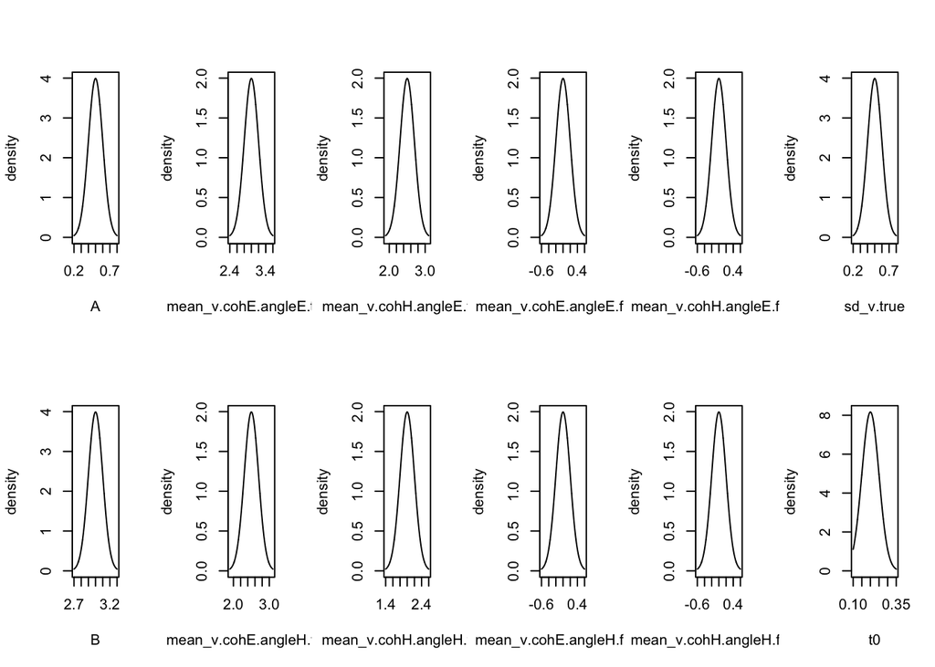

```r
# Population distribution, Coherence and Angle effect on accumulation rate

pop.mean <- c(A=0.5, B = 3,  mean_v.cohE.angleE.true = 3, mean_v.cohE.angleH.true = 2.5,
              mean_v.cohH.angleE.true = 2.5, mean_v.cohH.angleH.true = 2,
              mean_v.cohE.angleE.false = 0, mean_v.cohE.angleH.false = 0,
              mean_v.cohH.angleE.false = 0, mean_v.cohH.angleH.false = 0,
              sd_v.true=0.5,t0=.2)


pop.scale <-c(A=.1, B = .1,  mean_v.cohE.angleE.true = .2, mean_v.cohE.angleH.true = .2,
              mean_v.cohH.angleE.true = .2, mean_v.cohH.angleH.true = .2,
              mean_v.cohE.angleE.false = .2, mean_v.cohE.angleH.false = .2,
              mean_v.cohH.angleE.false = .2, mean_v.cohH.angleH.false = .2,
              sd_v.true=0.1, t0=.05)

check.p.vector(pop.mean,model2)
check.p.vector(pop.scale,model2)



pop.prior <- prior.p.dmc(
  dists = rep("tnorm",12),
  p1=pop.mean,p2=pop.scale,
  lower=c(0,0,NA,NA,NA,NA,NA,NA,NA,NA,0,.1),upper=c(NA,NA,NA,NA,NA,NA,NA,NA,NA,NA,NA,1)
)

##  Check population distributions
par(mfcol=c(2,6)); for (i in names(pop.prior)) plot.prior(i,pop.prior)
```

Simulate data: ns subjects, with n data point per design cell

```r
# Simulate some data
raw.data2 <- h.simulate.dmc(model2, p.prior = pop.prior, n = 250, ns = 40)
data.model2 <- data.model.dmc(raw.data2, model2)

# Take a look at parameters
ps <- round( attr(raw.data2, "parameters"), 2)
round(apply(ps,2,mean),2)
```

```
##                        A                        B  mean_v.cohE.angleE.true
##                     0.47                     2.97                     3.02
##  mean_v.cohE.angleH.true  mean_v.cohH.angleE.true  mean_v.cohH.angleH.true
##                     2.48                     2.48                     1.92
## mean_v.cohE.angleE.false mean_v.cohE.angleH.false mean_v.cohH.angleE.false
##                     0.02                     0.03                    -0.03
## mean_v.cohH.angleH.false                sd_v.true                       t0
##                     0.01                     0.54                     0.20
```

Plot data from a subject:

First column=response left, Rows = EasyCoh-EasyAngle, EasyCoh-HardAngle,HardCoh-EasyAngle, HardCoh-HardAngle

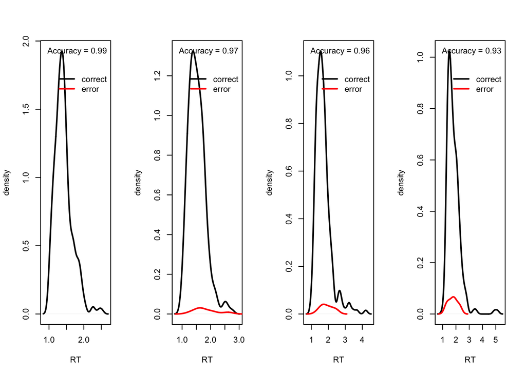

```r
# Take a look at the first  subject's data
par(mfcol=c(1,4))
for (i in 1) { # First column=response left, Second column = response right. Rows = EasyCoh-EasyAngle, EasyCoh-HardAngle,HardCoh-EasyAngle, hard-hard
  plot.cell.density(data.cell=data.model2[[i]][data.model2[[i]]$Coh=="cohE" & data.model2[[i]]$Angle=="angleE" & data.model2[[i]]$S=="s1",],C="r1",xlim=c(1,6),show.mean = TRUE)
  plot.cell.density(data.cell=data.model2[[i]][data.model2[[i]]$Coh=="cohE" & data.model2[[i]]$Angle=="angleH" & data.model2[[i]]$S=="s1",],C="r1",xlim=c(1,6),show.mean = TRUE)
  plot.cell.density(data.cell=data.model2[[i]][data.model2[[i]]$Coh=="cohH" & data.model2[[i]]$Angle=="angleE" & data.model2[[i]]$S=="s1",],C="r1",xlim=c(1,6),show.mean = TRUE)
  plot.cell.density(data.cell=data.model2[[i]][data.model2[[i]]$Coh=="cohH" & data.model2[[i]]$Angle=="angleH" & data.model2[[i]]$S=="s1",],C="r1",xlim=c(1,6),show.mean = TRUE)

}
```